# Machine Learning Assignment

## Group 35 Phase 2

Harold Li Guo Choi (s3866530)

Jessica Jiexi Lin (S3852191)

Vanessa Jie En Yew (s3817207)

1. Introduction
   > - Report Overview
   > - Overview Methodology
2. Predictive Modelling
   > - Feature Selection
   > - Model Fitting and Tuning
   > - Model Comparison
3. Critique and Limitations
4. Summary and Conclusions
5. References

# Introduction

## Report Overview

The Dream Housing Finance company plans to automate and gain insights about an applicant's loan eligibility based on specific details provided by the applicant. Through automation, they plan to segment customers who are eligible for their home loan from those who are not.

The aim of this project is to help the company recognise how to better position themselves to understand and offer loans to applicants through the use of data and machine learning. A machine learning model will be built to help Dream Housing Finance classify if a loan application should be approved based on various variables such as income, the loan amount and credit history.

After cleaning and processing the data as in phase one, the following insights were gained through the data visualisation and exploration stage:

Majority of the home loans are usually approved, with most applicants being male, graduates and have a good credit history. A positive credit history greatly affects the outcome of the loan status while being a graduate only has a small impact on the loan status. Majority of the applicants have a total monthly household income of less than 10,000 USD/month, and are requesting for loans amounting from 50k to 250k with a term of 360 days. The gender of the applicants do not contribute much to the outcome of the loan status. Female applicants who have their loans approved have a higher average household income as compared to the females who do not have their loan approved. The applicants from the Semi-Urbanised Area are most likely to be granted loans, followed by the Urbanised Area and then the Rural Area. Across all property areas, loans that are approved have a lower average loan amount.

With these insights in mind, the second phase of this project will explore different predictive modelling techniques using the dataset that was preprocessed and explored in phase one. Procedures like feature selection, hyperparameter tuning, cross-validation and model evaluation will be investigated in this report.

## Overview of Methodology

Building machine learning models require many considerations of the build. These considerations are often about finding a balance between building powerful predictive model, and keeping it generalisable by avoiding overfitting.

Firstly, preprocessing steps specific for the preparation of machine learning are performed. One-hot encoding and scaling of the descriptive features allows the data to be fed into Scikit-Learn's machine learning algorithms.

Feature selection is then performed to find the most predictive descriptive features. A filter method is chosen for this project because five different classifiers will be explored. This allows for a more concise and streamlined process to determine the best features. Since the dataset contains mild class imbalances, the random forest importance method is used to perform the feature selection. The random forest importance method is also the only method that gives a higher ROC_AUC score across all models when compared with the base models (models without feature selection).

A key step to prevent overfitting and promote generalisability in machine learning models is cross-validation. Many steps of building a machine learning model require cross-validation to ensure this. Since the dataset contains 480 observations with class imbalances, the repeated stratified cross-validation method with five folds and three repeats are used throughout the process. A random state of 999 is also set to ensure that the same split of data are run across all models.

Due to the nature of this particular data science problem, supervised machine learning models will be built to solve the problem. Specifically, five different classification algorithms will be utilised to help predict the target variable: k-nearest neighbour, naive bayes, decision tree, random forrest and logistic regression classifiers. Pipelines are used to then stack the feature selection and cross-validated hyperparameter tuning. Each classifier with a combination of hyperparameters and the feature selection method are fed through a pipeline to determine the combination for the best performing models based on their AUC score.

Once the best features are calculated and their corresponding number of features are found, the models are fitted to the test data. Their performances are compared through paired sample t-tests to determine if the results are statistically significant. Furthermore, classifications reports are also produced for each model for further performance metric analysis.

# Predictive Modelling

## Preprocessing

Firstly, the cleaned dataset must be transformed before being fed into Scikit-Learn's machine learning algorithms. The dataset is loaded and basic importation checks are performed.

```python
import warnings
warnings.filterwarnings("ignore")

import numpy as np
import pandas as pd
import io
from sklearn.model_selection import cross_val_score, RepeatedStratifiedKFold
import matplotlib.pyplot as plt
import seaborn as sns
%matplotlib inline
%config InlineBackend.figure_format = 'retina'
plt.style.use("ggplot")

# so that we can see all the columns
pd.set_option('display.max_columns', None)

from google.colab import files
uploaded = files.upload()

loan_df = pd.read_csv(io.BytesIO(uploaded['loan_clean.csv']))
print(loan_df)
```

```
Saving loan_clean.csv to loan_clean.csv
     Gender Married Dependents     Education Self_Employed  \
0      Male     Yes          1      Graduate            No
1      Male     Yes          0      Graduate           Yes
2      Male     Yes          0  Not Graduate            No
3      Male      No          0      Graduate            No
4      Male     Yes          2      Graduate           Yes
..      ...     ...        ...           ...           ...
475  Female      No          0      Graduate            No
476    Male     Yes         3+      Graduate            No
477    Male     Yes          1      Graduate            No
478    Male     Yes          2      Graduate            No
479  Female      No          0      Graduate           Yes

     TotalHouseholdIncome  LoanAmount  Loan_Amount_Term  Credit_History  \
```

[output cut: 26 more lines]

```python
loan_df.head(5)
```

|  | Gender | Married | Dependents | Education | Self_Employed | TotalHouseholdIncome | LoanAmount | Loan_Amount_Term | Credit_History | Property_Area | Loan_Status |
| --- | --- | --- | --- | --- | --- | --- | --- | --- | --- | --- | --- |
| 0 | Male | Yes | 1 | Graduate | No | 6091.0 | 128.0 | 360.0 | 1.0 | Rural | N |
| 1 | Male | Yes | 0 | Graduate | Yes | 3000.0 | 66.0 | 360.0 | 1.0 | Urban | Y |
| 2 | Male | Yes | 0 | Not Graduate | No | 4941.0 | 120.0 | 360.0 | 1.0 | Urban | Y |
| 3 | Male | No | 0 | Graduate | No | 6000.0 | 141.0 | 360.0 | 1.0 | Urban | Y |
| 4 | Male | Yes | 2 | Graduate | Yes | 9613.0 | 267.0 | 360.0 | 1.0 | Urban | Y |

```python
loan_df.describe(include='all')
```

|  | Gender | Married | Dependents | Education | Self_Employed | TotalHouseholdIncome | LoanAmount | Loan_Amount_Term | Credit_History | Property_Area | Loan_Status |
| --- | --- | --- | --- | --- | --- | --- | --- | --- | --- | --- | --- |
| count | 480 | 480 | 480 | 480 | 480 | 480.000000 | 480.000000 | 480.000000 | 480.000000 | 480 | 480 |
| unique | 2 | 2 | 4 | 2 | 2 | NaN | NaN | NaN | NaN | 3 | 2 |
| top | Male | Yes | 0 | Graduate | No | NaN | NaN | NaN | NaN | Semiurban | Y |
| freq | 394 | 311 | 274 | 383 | 414 | NaN | NaN | NaN | NaN | 191 | 332 |
| mean | NaN | NaN | NaN | NaN | NaN | 6945.324833 | 144.735417 | 342.050000 | 0.854167 | NaN | NaN |
| std | NaN | NaN | NaN | NaN | NaN | 5969.948374 | 80.508164 | 65.212401 | 0.353307 | NaN | NaN |
| min | NaN | NaN | NaN | NaN | NaN | 1442.000000 | 9.000000 | 36.000000 | 0.000000 | NaN | NaN |
| 25% | NaN | NaN | NaN | NaN | NaN | 4148.000000 | 100.000000 | 360.000000 | 1.000000 | NaN | NaN |
| 50% | NaN | NaN | NaN | NaN | NaN | 5422.500000 | 128.000000 | 360.000000 | 1.000000 | NaN | NaN |
| 75% | NaN | NaN | NaN | NaN | NaN | 7672.500000 | 170.000000 | 360.000000 | 1.000000 | NaN | NaN |
| max | NaN | NaN | NaN | NaN | NaN | 81000.000000 | 600.000000 | 480.000000 | 1.000000 | NaN | NaN |

```python
# separate data and target
target = loan_df['Loan_Status']
Data = loan_df.drop(columns='Loan_Status')
```

```python
target.value_counts()
```

```
Y    332
N    148
Name: Loan_Status, dtype: int64
```

The target shows a significant disparity between the number of positive and negative labels, therefore implying a class imbalanced problem.

### One-hot Encoding

Many machine learning algorithms are not able to work on labelled data directly and require all input and output variables to be numeric. One-hot encoding converts the categorical variables to a numerical form.

### Encoding of the Target Feature

The target variable is encoded such that the positive class 'Y' is encoded as '1'.

```python
target = target.replace({'N': 0, 'Y': 1})

target.value_counts()
```

```
1    332
0    148
Name: Loan_Status, dtype: int64
```

### Encoding of the Categorical Descriptive Features

This code is obtained from https://www.featureranking.com/tutorials/machine-learning-tutorials/data-preparation-for-machine-learning/#2.2.2

```python
#One Hot Encoding
Data_encoded = Data.copy()

# get the list of categorical descriptive features
categorical_cols = Data_encoded.columns[Data_encoded.dtypes==object].tolist()

# if a categorical descriptive feature has only 2 levels,
# define only one binary variable
for col in categorical_cols:
    n = len(Data_encoded[col].unique())
    if (n == 2):
        Data_encoded[col] = pd.get_dummies(Data_encoded[col], drop_first=True)

# for other categorical features (with > 2 levels),
# use regular one-hot-encoding
# if a feature is numeric, it will be untouched
loan_df = pd.get_dummies(Data_encoded)
loan_df.head(5)
```

|  | Gender | Married | Education | Self_Employed | TotalHouseholdIncome | LoanAmount | Loan_Amount_Term | Credit_History | Dependents_0 | Dependents_1 | Dependents_2 | Dependents_3+ | Property_Area_Rural | Property_Area_Semiurban | Property_Area_Urban |
| --- | --- | --- | --- | --- | --- | --- | --- | --- | --- | --- | --- | --- | --- | --- | --- |
| 0 | 1 | 1 | 0 | 0 | 6091.0 | 128.0 | 360.0 | 1.0 | 0 | 1 | 0 | 0 | 1 | 0 | 0 |
| 1 | 1 | 1 | 0 | 1 | 3000.0 | 66.0 | 360.0 | 1.0 | 1 | 0 | 0 | 0 | 0 | 0 | 1 |
| 2 | 1 | 1 | 1 | 0 | 4941.0 | 120.0 | 360.0 | 1.0 | 1 | 0 | 0 | 0 | 0 | 0 | 1 |
| 3 | 1 | 0 | 0 | 0 | 6000.0 | 141.0 | 360.0 | 1.0 | 1 | 0 | 0 | 0 | 0 | 0 | 1 |
| 4 | 1 | 1 | 0 | 1 | 9613.0 | 267.0 | 360.0 | 1.0 | 0 | 0 | 1 | 0 | 0 | 0 | 1 |

After one-hot encoding, the variable Education has been 0 assigned for Graduate and 1 assigned for Not Graduate. As it is a good practice to keep the postive class as 1, we will use the replace function to make the change.

```python
# encode Education with Graduate as 1, and Not Graduate as 0
loan_df['Education'] = loan_df['Education'].replace({0 : 1, 1 : 0})
```

```python
loan_df.head(5)
```

|  | Gender | Married | Education | Self_Employed | TotalHouseholdIncome | LoanAmount | Loan_Amount_Term | Credit_History | Dependents_0 | Dependents_1 | Dependents_2 | Dependents_3+ | Property_Area_Rural | Property_Area_Semiurban | Property_Area_Urban |
| --- | --- | --- | --- | --- | --- | --- | --- | --- | --- | --- | --- | --- | --- | --- | --- |
| 0 | 1 | 1 | 1 | 0 | 6091.0 | 128.0 | 360.0 | 1.0 | 0 | 1 | 0 | 0 | 1 | 0 | 0 |
| 1 | 1 | 1 | 1 | 1 | 3000.0 | 66.0 | 360.0 | 1.0 | 1 | 0 | 0 | 0 | 0 | 0 | 1 |
| 2 | 1 | 1 | 0 | 0 | 4941.0 | 120.0 | 360.0 | 1.0 | 1 | 0 | 0 | 0 | 0 | 0 | 1 |
| 3 | 1 | 0 | 1 | 0 | 6000.0 | 141.0 | 360.0 | 1.0 | 1 | 0 | 0 | 0 | 0 | 0 | 1 |
| 4 | 1 | 1 | 1 | 1 | 9613.0 | 267.0 | 360.0 | 1.0 | 0 | 0 | 1 | 0 | 0 | 0 | 1 |

$\mbox{scaled_value} = \frac{\mbox{value - min_value}}{\mbox{max_value - min_value}}$

The goal the min-max scaler is to make every datapoint have the same scale so each feature is equally important.

```python
# scale descriptive features with min max scaling
from sklearn import preprocessing

Data_encoded_norm_numpy= preprocessing.MinMaxScaler().fit_transform(loan_df)
Data_encoded_norm_numpy
```

```
array([[1., 1., 1., ..., 1., 0., 0.],
       [1., 1., 1., ..., 0., 0., 1.],
       [1., 1., 0., ..., 0., 0., 1.],
       ...,
       [1., 1., 1., ..., 0., 0., 1.],
       [1., 1., 1., ..., 0., 0., 1.],
       [0., 0., 1., ..., 0., 1., 0.]])
```

```python
# recombine scaled and encoded features with target to assess transformations
Data_encoded_norm_df = pd.DataFrame(Data_encoded_norm_numpy, columns=loan_df.columns)
df_clean = Data_encoded_norm_df.assign(target = target)
df_clean.head(10)
```

|  | Gender | Married | Education | Self_Employed | TotalHouseholdIncome | LoanAmount | Loan_Amount_Term | Credit_History | Dependents_0 | Dependents_1 | Dependents_2 | Dependents_3+ | Property_Area_Rural | Property_Area_Semiurban | Property_Area_Urban | target |
| --- | --- | --- | --- | --- | --- | --- | --- | --- | --- | --- | --- | --- | --- | --- | --- | --- |
| 0 | 1.0 | 1.0 | 1.0 | 0.0 | 0.058435 | 0.201354 | 0.72973 | 1.0 | 0.0 | 1.0 | 0.0 | 0.0 | 1.0 | 0.0 | 0.0 | 0 |
| 1 | 1.0 | 1.0 | 1.0 | 1.0 | 0.019583 | 0.096447 | 0.72973 | 1.0 | 1.0 | 0.0 | 0.0 | 0.0 | 0.0 | 0.0 | 1.0 | 1 |
| 2 | 1.0 | 1.0 | 0.0 | 0.0 | 0.043980 | 0.187817 | 0.72973 | 1.0 | 1.0 | 0.0 | 0.0 | 0.0 | 0.0 | 0.0 | 1.0 | 1 |
| 3 | 1.0 | 0.0 | 1.0 | 0.0 | 0.057292 | 0.223350 | 0.72973 | 1.0 | 1.0 | 0.0 | 0.0 | 0.0 | 0.0 | 0.0 | 1.0 | 1 |
| 4 | 1.0 | 1.0 | 1.0 | 1.0 | 0.102705 | 0.436548 | 0.72973 | 1.0 | 0.0 | 0.0 | 1.0 | 0.0 | 0.0 | 0.0 | 1.0 | 1 |
| 5 | 1.0 | 1.0 | 0.0 | 0.0 | 0.030255 | 0.145516 | 0.72973 | 1.0 | 1.0 | 0.0 | 0.0 | 0.0 | 0.0 | 0.0 | 1.0 | 1 |
| 6 | 1.0 | 1.0 | 1.0 | 0.0 | 0.051510 | 0.252115 | 0.72973 | 0.0 | 0.0 | 0.0 | 0.0 | 1.0 | 0.0 | 1.0 | 0.0 | 0 |
| 7 | 1.0 | 1.0 | 1.0 | 0.0 | 0.051409 | 0.269036 | 0.72973 | 1.0 | 0.0 | 0.0 | 1.0 | 0.0 | 0.0 | 0.0 | 1.0 | 1 |
| 8 | 1.0 | 1.0 | 1.0 | 0.0 | 0.281141 | 0.575296 | 0.72973 | 1.0 | 0.0 | 1.0 | 0.0 | 0.0 | 0.0 | 1.0 | 0.0 | 0 |
| 9 | 1.0 | 1.0 | 1.0 | 0.0 | 0.030896 | 0.103215 | 0.72973 | 1.0 | 0.0 | 0.0 | 1.0 | 0.0 | 0.0 | 0.0 | 1.0 | 1 |

```python
# convert to numpy objects for scikit-learn
Data = Data_encoded_norm_numpy  #already a numpy object
target = target
```

## Feature Selection

High dimensionality data may contain redundant features. These redundacy of features will significantly increase the training time of the machine learning model. Furthermore redundant features overcomplicates the model and often leads to overfitting. Therefore, feature selection will be used to extract the most important and relevant features of the dataset to achieve the most effective predictive modeling performance.

Different feature selection methods such as the F-Score, Mutual Information, Random Forest Importance and Chi-square, are run on the model. The Random Forest Importance with 100 estimators is chosen to be the feature selection method as it is the only method that produces a higher accuracy score across all classifiers when compared to the base models (the base models are the different classifer models with full features).

### Random Forest Importance Method

The ten most relevant features selected by the Random Forest Importance (RFI) method are displayed below to give insight into the problem at hand.

The number of features of the RFI will be included in the pipeline during the hyperparameter tuning phase to determine the number of features that works best with each classifer.

```python
from sklearn.ensemble import RandomForestClassifier

num_features = 10
model_rfi = RandomForestClassifier(n_estimators=100)
model_rfi.fit(Data, target)
fs_indices_rfi = np.argsort(model_rfi.feature_importances_)[::-1][0:num_features]

best_features_rfi = loan_df.columns[fs_indices_rfi].values
best_features_rfi
```

```
array(['TotalHouseholdIncome', 'Credit_History', 'LoanAmount',
       'Loan_Amount_Term', 'Married', 'Education', 'Gender',
       'Self_Employed', 'Property_Area_Semiurban', 'Property_Area_Rural'],
      dtype=object)
```

```python
feature_importances_rfi = model_rfi.feature_importances_[fs_indices_rfi]
feature_importances_rfi
```

```
array([0.25526707, 0.24611047, 0.22498627, 0.04915885, 0.02870359,
       0.02787545, 0.02628608, 0.02313896, 0.02083008, 0.01989469])
```

```python
import matplotlib.pyplot as plt
%matplotlib inline
%config InlineBackend.figure_format = 'retina'
plt.style.use("ggplot")

def plot_imp(best_features, scores, method_name):
    plt.barh(best_features, scores)
    plt.title(method_name + ' Feature Importances')
    plt.xlabel("Importance")
    plt.ylabel("Features")
    plt.show()
```

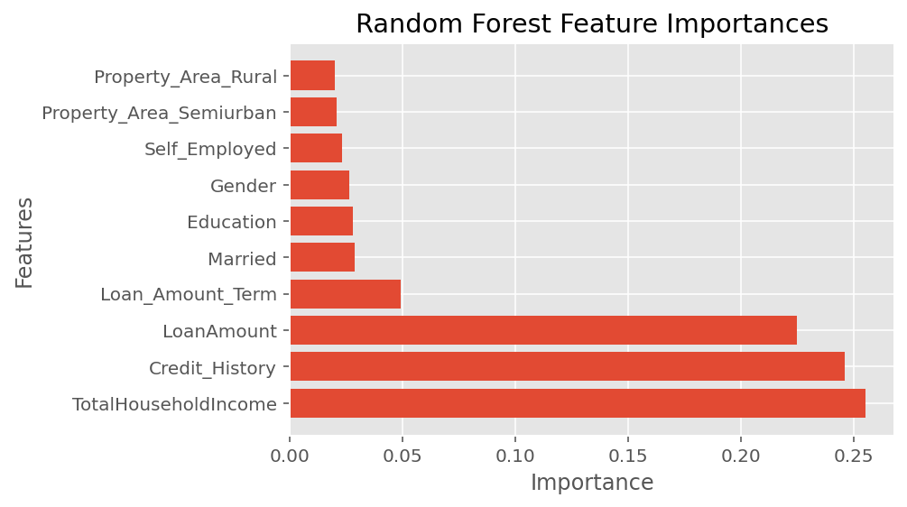

```python
plot_imp(best_features_rfi, feature_importances_rfi, 'Random Forest')
```

The most important feature as observed is total household income, credit history and then loan amount. The top ten features coincide with the those that have been identified during the data visualisation and exploration stage.

Based on the plot, top three features have higher weightage in terms of importance as their score of importance are far beyond the other features. It is therefore decided that the number of features to be tested are 1, 3, 5, 10 and 15 (full feature) features.

### Train Test Split and Model Evaluation Strategy

The model is split into 7:3 ratio where 70% of the data will be use for training and the remaining 30% will be used for testing.

As the dataset only contains 480 rows, the Repeated Stratified KFold cross validation evaluation method is then used for hyperparameter tuning. StatifiedKFold is chosen as the cross-validation method as the data set has a slight imbalance issue, containing 332 positive and 148 negative target cases.

Since the target labels have fewer loans rejection `(~30%)` than approval `(~70%)`, the stratification method ensures that the proportion of the levels in both train and test sets are the same as the proportion in the full dataset in each cross-validation repetition.

A 5 fold cross validation with 3 repetition will be used for hyper-parameter tuning.

Receiver Operating Characteristic Curve (ROC AUC) is used as our evaluation metric as there is a binary classification problem. Furthermore, ROC AUC is sensitive to the slight class imbalance issue in the dataset.

```python
from sklearn.model_selection import train_test_split

D_train, D_test, t_train, t_test = train_test_split(Data,
                                                    target,
                                                    test_size = 0.3,
                                                    random_state= 999,
                                                    stratify = target,
                                                    shuffle = True)
```

```python
cv_method = RepeatedStratifiedKFold(n_splits=5,
                                     n_repeats=3,
                                     random_state=999)

scoring_metric = 'roc_auc'
```

## Model Fitting and Hyperparameter tuning

A pipeline is used to stack both feature selection and the grid search for hyperparameter tuning of the classifiers via cross-validation.

For feature selection, the pipeline will run through 1, 3, 5, 10 and the full set of features (15) to determine the number of features that works best with each classifer.

Given there is a mild class imbalance in the target feature, the **ROC_AUC** metric is chosen as the scoring method as it is robust to such issues.

The **ROC_AUC** is also chosen as the scoring metric as it provides a balance between True Positive Rate (TPR) and False Positive Rate (FPR).

Both the TPR and the FPR are important to the Dream Housing Finance Company. As a loan company, the Dream Housing Finance Company earns its income by providing mortgage loans to their clients and charging them an interest for it. It is therefore important that the people who should get their loans approved are correctly identified.

At the same time, the company would also hope to acheive a low FPR. If a customer is incorrectly identified, it will result in more loans being defaulted.

The following `RFIFeatureSelector()` class code is to pass in RFI as a step to the pipeline. This code is obtain from: https://www.featureranking.com/tutorials/machine-learning-tutorials/case-study-predicting-income-status/

```python
from sklearn.base import BaseEstimator, TransformerMixin

# custom function for RFI feature selection inside a pipeline
# here we use n_estimators=100
class RFIFeatureSelector(BaseEstimator, TransformerMixin):

    # class constructor
    # make sure class attributes end with a "_"
    # per scikit-learn convention to avoid errors
    def __init__(self, n_features_=10):
        self.n_features_ = n_features_
        self.fs_indices_ = None

    # override the fit function
    def fit(self, X, y):
        from sklearn.ensemble import RandomForestClassifier
        from numpy import argsort
        model_rfi = RandomForestClassifier(n_estimators=100)
        model_rfi.fit(X, y)
        self.fs_indices_ = argsort(model_rfi.feature_importances_)[::-1][0:self.n_features_]
        return self

    # override the transform function
    def transform(self, X, y=None):
        return X[:, self.fs_indices_]
```

### K-Nearest Neighbors (KNN)

The hyperparameters to be tuned and tested for the KNN classifier are as follows:

```python
from sklearn.pipeline import Pipeline
from sklearn.neighbors import KNeighborsClassifier
from sklearn.model_selection import GridSearchCV

pipe_KNN = Pipeline(steps=[('rfi_fs', RFIFeatureSelector()),
                           ('knn', KNeighborsClassifier())])

params_pipe_KNN = {'rfi_fs__n_features_': [1, 3, 5, 10, Data.shape[1]],
                   'knn__n_neighbors': [5, 7, 10, 15],
                   'knn__p': [1, 2, 5]}

gs_pipe_KNN = GridSearchCV(estimator=pipe_KNN,
                           param_grid=params_pipe_KNN,
                           cv=cv_method,
                           refit=True,
                           n_jobs=-2,
                           scoring='roc_auc',
                           verbose=1)
```

```python
gs_pipe_KNN.fit(D_train, t_train)
```

```
Fitting 15 folds for each of 60 candidates, totalling 900 fits
```

```
[Parallel(n_jobs=-2)]: Using backend SequentialBackend with 1 concurrent workers.
[Parallel(n_jobs=-2)]: Done 900 out of 900 | elapsed:  2.2min finished
```

```
GridSearchCV(cv=RepeatedStratifiedKFold(n_repeats=3, n_splits=5, random_state=999),
             error_score=nan,
             estimator=Pipeline(memory=None,
                                steps=[('rfi_fs',
                                        RFIFeatureSelector(n_features_=10)),
                                       ('knn',
                                        KNeighborsClassifier(algorithm='auto',
                                                             leaf_size=30,
                                                             metric='minkowski',
                                                             metric_params=None,
                                                             n_jobs=None,
                                                             n_neighbors=5, p=2,
                                                             weights='uniform'))],
                                verbose=False),
             iid='deprecated', n_jobs=-2,
             param_grid={'knn__n_neighbors': [5, 7, 10, 15],
                         'knn__p': [1, 2, 5],
                         'rfi_fs__n_features_': [1, 3, 5, 10, 15]},
             pre_dispatch='2*n_jobs', refit=True, return_train_score=False,
             scoring='roc_auc', verbose=1)
```

```python
gs_pipe_KNN.best_params_
```

```
{'knn__n_neighbors': 15, 'knn__p': 1, 'rfi_fs__n_features_': 3}
```

```python
gs_pipe_KNN.best_score_.round(3)
```

```
0.768
```

The optimal parameter values obtained after repeated stratified folds is as follows:

1. number of neighbors (n_neighbors) : 15
2. the distance metric p: 1 (Manhattan)

The number of features selected via the RFI pipline is 3 features. These parameters produced a KNN model with a mean AUC score of 0.768.

Other combinations of parameters and number of RFI features are also considered to determine if the difference is significant.

The following function is to format the grid search output as a Pandas dataframe. The code is obtained from: https://www.featureranking.com/tutorials/machine-learning-tutorials/case-study-predicting-income-status/

```python
# custom function to format the search results as a Pandas data frame
def get_search_results(gs):

    def model_result(scores, params):
        scores = {'mean_score': np.mean(scores),
             'std_score': np.std(scores),
             'min_score': np.min(scores),
             'max_score': np.max(scores)}
        return pd.Series({**params,**scores})

    models = []
    scores = []

    for i in range(gs.n_splits_):
        key = f"split{i}_test_score"
        r = gs.cv_results_[key]
        scores.append(r.reshape(-1,1))

    all_scores = np.hstack(scores)
    for p, s in zip(gs.cv_results_['params'], all_scores):
        models.append((model_result(s, p)))

    pipe_results = pd.concat(models, axis=1).T.sort_values(['mean_score'], ascending=False)

    columns_first = ['mean_score', 'std_score', 'max_score', 'min_score']
    columns = columns_first + [c for c in pipe_results.columns if c not in columns_first]

    return pipe_results[columns]
```

There is only a minor difference between the different hyperparameter combination. Regardless of the combination, the optimal number of features selected by the RFI method is 3 features.

```python
results_KNN = get_search_results(gs_pipe_KNN)
results_KNN.head(10).round(3)
```

|  | mean_score | std_score | max_score | min_score | knn__n_neighbors | knn__p | rfi_fs__n_features_ |
| --- | --- | --- | --- | --- | --- | --- | --- |
| 46 | 0.768 | 0.054 | 0.880 | 0.675 | 15.0 | 1.0 | 3.0 |
| 51 | 0.767 | 0.057 | 0.904 | 0.690 | 15.0 | 2.0 | 3.0 |
| 56 | 0.762 | 0.062 | 0.887 | 0.675 | 15.0 | 5.0 | 3.0 |
| 36 | 0.759 | 0.051 | 0.879 | 0.671 | 10.0 | 2.0 | 3.0 |
| 31 | 0.758 | 0.055 | 0.880 | 0.667 | 10.0 | 1.0 | 3.0 |
| 26 | 0.753 | 0.053 | 0.854 | 0.656 | 7.0 | 5.0 | 3.0 |
| 41 | 0.751 | 0.053 | 0.877 | 0.668 | 10.0 | 5.0 | 3.0 |
| 11 | 0.747 | 0.052 | 0.879 | 0.653 | 5.0 | 5.0 | 3.0 |
| 16 | 0.746 | 0.058 | 0.891 | 0.656 | 7.0 | 1.0 | 3.0 |
| 21 | 0.744 | 0.060 | 0.901 | 0.639 | 7.0 | 2.0 | 3.0 |

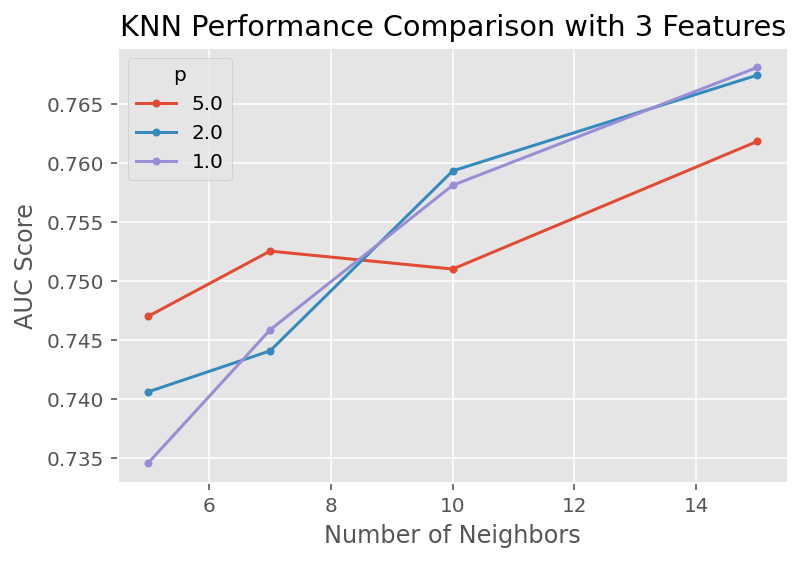

```python
results_KNN_3_features = results_KNN[results_KNN['rfi_fs__n_features_'] == 3].sort_values('knn__n_neighbors')

for i in results_KNN_3_features['knn__p'].unique():
    temp = results_KNN_3_features[results_KNN_3_features['knn__p'] == i]
    plt.plot(temp['knn__n_neighbors'], temp['mean_score'], marker = '.', label = i)

plt.legend(title = "p")
plt.xlabel('Number of Neighbors')
plt.ylabel("AUC Score")
plt.title("KNN Performance Comparison with 3 Features")
plt.show()
```

With number of features fixed at 3, at lower number of neighbours (up to 9 nearest neighbour), the Minkowski distance metric in red would obtain a higher AUC score as compared to the other distance calculation methods.

For number of neighbours between 9 to 13, the Euclidean distance metric in blue would obtain a higher AUC score as compared to the other distance matrix. While at the number of neighbours equals 14 and 15, the Manhattan in purple obtained a higher AUC score.

### Naive Bayes (NB)

The Naive Bayes model only has one hyperparameter to be tuned. The `var_smoothing` hyperparameter is optimised through a grid search which is conducted in the log space which runs from $10$ to $ 10^{-3}$ with 200 values between. To save time, a random search will be run across 20 different values.

Power transformation is performed using the `PowerTransformer` method in sklearn to make each feature more or less normally distributed as the Gaussian Naive Bayes method assumes that each one of the descriptive features follows a Gaussian, that is, normal distribution. By default, `PowerTransformer` results in features that have a 0 mean and 1 standard deviation.

```python
from sklearn.preprocessing import PowerTransformer
Data_train_transformed = PowerTransformer().fit_transform(D_train)
```

```python
from sklearn.naive_bayes import GaussianNB
from sklearn.model_selection import RandomizedSearchCV

pipe_NB = Pipeline([('rfi_fs', RFIFeatureSelector()),
                     ('nb', GaussianNB())])

params_pipe_NB = {'rfi_fs__n_features_': [1, 3, 5, 10, Data.shape[1]],
                  'nb__var_smoothing': np.logspace(1,-3, num=200)}

n_iter_search = 20
gs_pipe_NB = RandomizedSearchCV(estimator=pipe_NB,
                          param_distributions=params_pipe_NB,
                          cv=cv_method,
                          refit=True,
                          n_jobs=-2,
                          scoring='roc_auc',
                          n_iter=n_iter_search,
                          verbose=1)

gs_pipe_NB.fit(Data_train_transformed, t_train);
```

```
Fitting 15 folds for each of 20 candidates, totalling 300 fits
```

```
[Parallel(n_jobs=-2)]: Using backend SequentialBackend with 1 concurrent workers.
[Parallel(n_jobs=-2)]: Done 300 out of 300 | elapsed:   43.4s finished
```

```python
gs_pipe_NB.best_params_
```

```
{'nb__var_smoothing': 0.009221978823334321, 'rfi_fs__n_features_': 10}
```

```python
gs_pipe_NB.best_score_.round(3)
```

```
0.754
```

The optimal parameter values obtained after repeated stratified is as follows:

1. var_smoothing: 0.009

While the number of features selected via the RFI pipline is 10 features. These optimal parameters produced a mean AUC score of 0.754.

The NB model yields a slightly lower score as compared to the KNN model. However, we cannot conclude that the KNN model out performs the NB model at this point. A paired T-test on the test data would be required to come to a conclusion.

```python
results_NB = get_search_results(gs_pipe_NB)
results_NB.head(10).round(3)
```

|  | mean_score | std_score | max_score | min_score | rfi_fs__n_features_ | nb__var_smoothing |
| --- | --- | --- | --- | --- | --- | --- |
| 18 | 0.754 | 0.055 | 0.859 | 0.647 | 10.0 | 0.009 |
| 10 | 0.753 | 0.060 | 0.858 | 0.645 | 10.0 | 0.494 |
| 11 | 0.752 | 0.055 | 0.855 | 0.669 | 15.0 | 2.613 |
| 1 | 0.751 | 0.061 | 0.858 | 0.643 | 10.0 | 1.804 |
| 14 | 0.750 | 0.053 | 0.851 | 0.674 | 15.0 | 0.988 |
| 8 | 0.748 | 0.051 | 0.843 | 0.664 | 15.0 | 0.141 |
| 12 | 0.747 | 0.051 | 0.844 | 0.667 | 15.0 | 0.297 |
| 6 | 0.742 | 0.073 | 0.869 | 0.611 | 5.0 | 0.283 |
| 17 | 0.742 | 0.053 | 0.822 | 0.635 | 10.0 | 0.002 |
| 9 | 0.737 | 0.080 | 0.855 | 0.568 | 3.0 | 0.196 |

There is only a minute difference between the different hyperparameter combination. Regardless of the combination, the most common optimal number of features selected by the RFI method is 10 features.

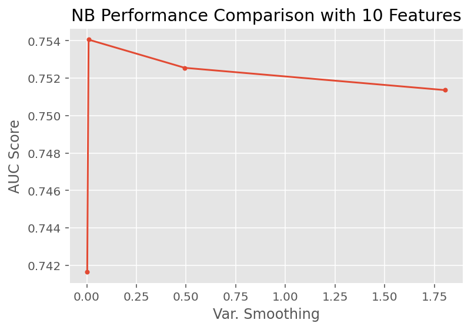

```python
results_NB_10_features = results_NB[results_NB['rfi_fs__n_features_'] == 10.0].sort_values('nb__var_smoothing')

plt.plot(results_NB_10_features['nb__var_smoothing'], results_NB_10_features['mean_score'], marker = '.', label = i)
plt.xlabel('Var. Smoothing')
plt.ylabel("AUC Score")
plt.title("NB Performance Comparison with 10 Features")
plt.show()
```

The AUC score increases exponentially at low levels of var.smoothing value till it reaches a max mean AUC score at 0.754 at var.smoothing value of 0.009 and then decreases after.

### Decision Tree (DT)

The decision tree classifier has three hyperparameters to be tuned:

1. criterion: gini, entropy
2. max_depth: 3, 4, 5
3. min_samples_split: 2, 3

A pipeline is created to stack the feature selection and hyperparameter tuning processess.

```python
from sklearn.tree import DecisionTreeClassifier

pipe_DT = Pipeline([('rfi_fs', RFIFeatureSelector()),
                    ('dt', DecisionTreeClassifier(random_state=999))])

params_pipe_DT = {'rfi_fs__n_features_': [1, 3, 5, 10, Data.shape[1]],
                  'dt__criterion': ['gini', 'entropy'],
                  'dt__max_depth': [ 3, 4, 5],
                  'dt__min_samples_split': [2,3]}

gs_pipe_DT = GridSearchCV(estimator=pipe_DT,
                          param_grid=params_pipe_DT,
                          cv=cv_method,
                          refit=True,
                          n_jobs=-2,
                          scoring='roc_auc',
                          verbose=1)

gs_pipe_DT.fit(D_train, t_train);
```

```
Fitting 15 folds for each of 60 candidates, totalling 900 fits
```

```
[Parallel(n_jobs=-2)]: Using backend SequentialBackend with 1 concurrent workers.
[Parallel(n_jobs=-2)]: Done 900 out of 900 | elapsed:  2.2min finished
```

```python
gs_pipe_DT.best_params_
```

```
{'dt__criterion': 'entropy',
 'dt__max_depth': 3,
 'dt__min_samples_split': 2,
 'rfi_fs__n_features_': 10}
```

```python
gs_pipe_DT.best_score_.round(3)
```

```
0.727
```

The optimal parameter values obtained is as follows:

1. criterion: entropy
2. max_depth: 3
3. min_samples_split: 2

The number of features selected via the RFI pipline is 10 features. The combination of these parameters produced a decision tree model with a mean AUC score of 0.727.

More combinations of the hyperparameters are explored in the plot below to observe how the AUC score changes with the different combinations of parameters.

```python
results_DT = get_search_results(gs_pipe_DT)
results_DT.head()
```

|  | mean_score | std_score | max_score | min_score | dt__criterion | dt__max_depth | dt__min_samples_split | rfi_fs__n_features_ |
| --- | --- | --- | --- | --- | --- | --- | --- | --- |
| 33 | 0.726641 | 0.0491814 | 0.803951 | 0.621074 | entropy | 3 | 2 | 10 |
| 26 | 0.724607 | 0.0727734 | 0.840062 | 0.539007 | gini | 5 | 3 | 3 |
| 18 | 0.721299 | 0.0649172 | 0.8147 | 0.58612 | gini | 4 | 3 | 10 |
| 34 | 0.721209 | 0.0444997 | 0.797619 | 0.621074 | entropy | 3 | 2 | 15 |
| 13 | 0.720746 | 0.0634862 | 0.8147 | 0.58612 | gini | 4 | 2 | 10 |

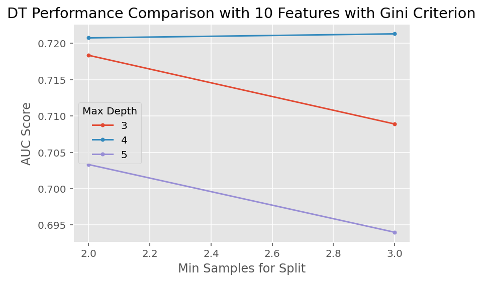

```python
# plot decision tree hyperparameter tuning comparion (gini)
results_DT = get_search_results(gs_pipe_DT)
results_DT_10_features = results_DT[results_DT['rfi_fs__n_features_'] == 10].sort_values('dt__min_samples_split')


for i in results_DT_10_features['dt__max_depth'].unique():
    temp = results_DT_10_features[(results_DT_10_features['dt__max_depth'] == i) & (results_DT_10_features['dt__criterion'] == "gini")]
    plt.plot(temp['dt__min_samples_split'], temp['mean_score'], marker = '.', label = i)

plt.legend(title = "Max Depth")
plt.xlabel('Min Samples for Split')
plt.ylabel("AUC Score")
plt.title("DT Performance Comparison with 10 Features with Gini Criterion")
plt.show()
```

The DT model (Gini Criterion) has an increase AUC score with the increase in the Min sample split for models with a max depth of 4. On the other hand, models with a max depth of 3 and 5 have an AUC score that decreases with the increase in min sample splits.

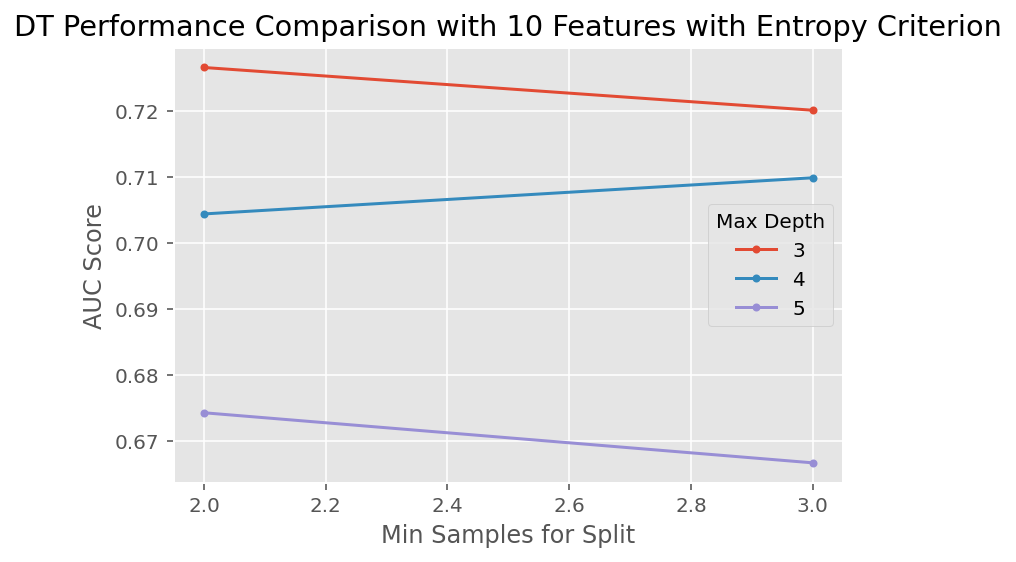

```python
# plot decision tree hyperparameter tuning comparion (entropy)
results_DT = get_search_results(gs_pipe_DT)
results_DT_10_features = results_DT[results_DT['rfi_fs__n_features_'] == 10].sort_values('dt__min_samples_split')


for i in results_DT_10_features['dt__max_depth'].unique():
    temp = results_DT_10_features[(results_DT_10_features['dt__max_depth'] == i) & (results_DT_10_features['dt__criterion'] == "entropy")]
    plt.plot(temp['dt__min_samples_split'], temp['mean_score'], marker = '.', label = i)

plt.legend(title = "Max Depth")
plt.xlabel('Min Samples for Split')
plt.ylabel("AUC Score")
plt.title("DT Performance Comparison with 10 Features with Entropy Criterion")
plt.show()
```

The DT model (Entropy Criterion) has an increase AUC score with the increase in the Min sample split models with max depth of 4, on the other hand, the mean AUC scores decreases with the increase in min sample split for models with max depth of 3 and 5. Despite the AUC score decaying with min_samples_split when max_depth = 3, it still produces the highest AUC score overall.

### Random Forest (RF)

Similar to the decision tree classifier, the random forest classifier has three hyperparameters to be tuned. The random forest will using both gini index and entropy method to determine which would produce a the best optimal model.

The following are the hyperparameters to be considered:

1. criterion: gini, entropy
2. max_depth: 3, 4, 5
3. min_samples_split: 2, 3

```python
from sklearn.ensemble import RandomForestClassifier

# pipeline for RF
pipe_RF = Pipeline([('rfi_fs', RFIFeatureSelector()),
                    ('rf', RandomForestClassifier(n_estimators=100,random_state=999))])

params_pipe_RF = {'rfi_fs__n_features_': [1, 3, 5, 10, Data.shape[1]],
                  'rf__criterion': ['gini', 'entropy'],
                  'rf__max_depth': [ 3, 4, 5],
                  'rf__min_samples_split': [2,3]}

gs_pipe_RF = GridSearchCV(estimator=pipe_RF,
                          param_grid=params_pipe_RF,
                          cv=cv_method,
                          refit=True,
                          n_jobs=-2,
                          scoring='roc_auc',
                          verbose=1)

gs_pipe_RF.fit(D_train, t_train);
```

```
Fitting 15 folds for each of 60 candidates, totalling 900 fits
```

```
[Parallel(n_jobs=-2)]: Using backend SequentialBackend with 1 concurrent workers.
[Parallel(n_jobs=-2)]: Done 900 out of 900 | elapsed:  4.2min finished
```

```python
gs_pipe_RF.best_params_
```

[output not shown]

```python
gs_pipe_RF.best_score_.round(3)
```

```
0.768
```

The pipeline also indicates for the random forest classifier, only three selected features are required for the optimised model. This model produced an average AUC score of 0.768 across the repeated folds.

Again, different combinations of hyperparameters for the random forrest classifier will be explored visually by plotting the AUC score against the hyperparameters.

```python
results_RF = get_search_results(gs_pipe_RF)
results_RF.head()
```

|  | mean_score | std_score | max_score | min_score | rf__criterion | rf__max_depth | rf__min_samples_split | rfi_fs__n_features_ |
| --- | --- | --- | --- | --- | --- | --- | --- | --- |
| 36 | 0.76838 | 0.0560031 | 0.871636 | 0.67766 | entropy | 3 | 3 | 3 |
| 41 | 0.767473 | 0.056501 | 0.865942 | 0.690426 | entropy | 4 | 2 | 3 |
| 6 | 0.765564 | 0.0514322 | 0.88147 | 0.696555 | gini | 3 | 3 | 3 |
| 48 | 0.765416 | 0.0541262 | 0.863354 | 0.651139 | entropy | 4 | 3 | 10 |
| 33 | 0.765099 | 0.0566806 | 0.851967 | 0.640787 | entropy | 3 | 2 | 10 |

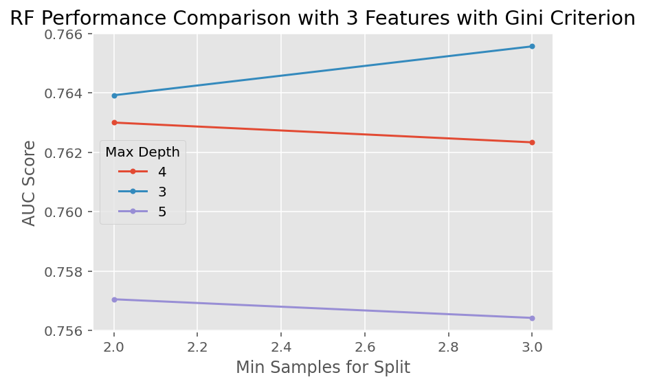

```python
results_RF = get_search_results(gs_pipe_RF)
results_RF_3_features = results_RF[results_RF['rfi_fs__n_features_'] == 3].sort_values('rf__min_samples_split')

# plot RF hyperparameter comparison (gini)
for i in results_RF_3_features['rf__max_depth'].unique():
    temp = results_RF_3_features[(results_RF_3_features['rf__max_depth'] == i) & (results_RF_3_features['rf__criterion'] == "gini")]
    plt.plot(temp['rf__min_samples_split'], temp['mean_score'], marker = '.', label = i)

plt.legend(title = "Max Depth")
plt.xlabel('Min Samples for Split')
plt.ylabel("AUC Score")
plt.title("RF Performance Comparison with 3 Features with Gini Criterion")
plt.show()
```

From the performance comparison plot of the hyperparameters with the Gini criterion, it can be observed when max_depth = 4 or 5, the AUC score decreases with min_samples_split. On the other hand, when max_depth = 3, the AUC score increases with min_samples_split and produces the highest overall AUC score.

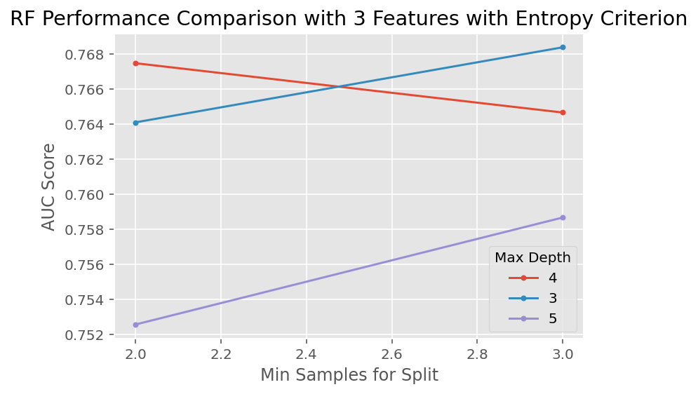

```python
# plot RF hyperparameter comparison (entropy)
for i in results_RF_3_features['rf__max_depth'].unique():
    temp = results_RF_3_features[(results_RF_3_features['rf__max_depth'] == i) & (results_RF_3_features['rf__criterion'] == "entropy")]
    plt.plot(temp['rf__min_samples_split'], temp['mean_score'], marker = '.', label = i)

plt.legend(title = "Max Depth")
plt.xlabel('Min Samples for Split')
plt.ylabel("AUC Score")
plt.title("RF Performance Comparison with 3 Features with Entropy Criterion")
plt.show()
```

While when the criterion for the decision tree is set to entropy, when max depth = 3 and 5, AUC score increases with the increase of min_samples_split. On the other hand, when max_score =4, the AUC score appear to decrease with min_samples_split. Overall, when max_depth = 3 it produces the highest AUC score.

### Logistic Regression

The following are the hyperparameters to be considered:

1. penalty: l1, l2
2. C: 100, 10, 1.0, 0.1, 0.01

```python
from sklearn.linear_model import LogisticRegression

# pipeline for logistic regression classifier
pipe_LR = Pipeline([('rfi_fs', RFIFeatureSelector()),
                    ('lr', LogisticRegression(random_state=999, solver = "liblinear"))])

params_pipe_LR = {'rfi_fs__n_features_': [1, 3, 5, 10, Data.shape[1]],
                  'lr__penalty': ['l1', 'l2'],
                  'lr__C': [ 100, 10, 1.0, 0.1, 0.01]}

gs_pipe_LR = GridSearchCV(estimator=pipe_LR,
                          param_grid=params_pipe_LR,
                          cv=cv_method,
                          refit=True,
                          n_jobs=-2,
                          scoring='roc_auc',
                          verbose=1)

gs_pipe_LR.fit(D_train, t_train);
```

```
Fitting 15 folds for each of 50 candidates, totalling 750 fits
```

```
[Parallel(n_jobs=-2)]: Using backend SequentialBackend with 1 concurrent workers.
[Parallel(n_jobs=-2)]: Done 750 out of 750 | elapsed:  1.8min finished
```

```python
gs_pipe_LR.best_params_
```

```
{'lr__C': 0.1, 'lr__penalty': 'l2', 'rfi_fs__n_features_': 15}
```

```python
gs_pipe_LR.best_score_.round(3)
```

```
0.766
```

The pipeline has indicated the best parameters for the logistic regression classifer are:

1. penalty = l2
2. C = 0.1

It also shows that all fifteen features are needed to create the most predicitve model for a logistic regression classifier. This optimised model produced a mean AUC score of 0.766.

```python
results_LR = get_search_results(gs_pipe_LR)
results_LR.head()
```

|  | mean_score | std_score | max_score | min_score | lr__C | lr__penalty | rfi_fs__n_features_ |
| --- | --- | --- | --- | --- | --- | --- | --- |
| 39 | 0.766048 | 0.0470696 | 0.863354 | 0.668737 | 0.1 | l2 | 15 |
| 38 | 0.763801 | 0.0473313 | 0.869565 | 0.643892 | 0.1 | l2 | 10 |
| 29 | 0.76079 | 0.0495978 | 0.859213 | 0.671843 | 1 | l2 | 15 |
| 18 | 0.757306 | 0.0541213 | 0.855072 | 0.669706 | 10 | l2 | 10 |
| 28 | 0.755101 | 0.052698 | 0.86853 | 0.671843 | 1 | l2 | 10 |

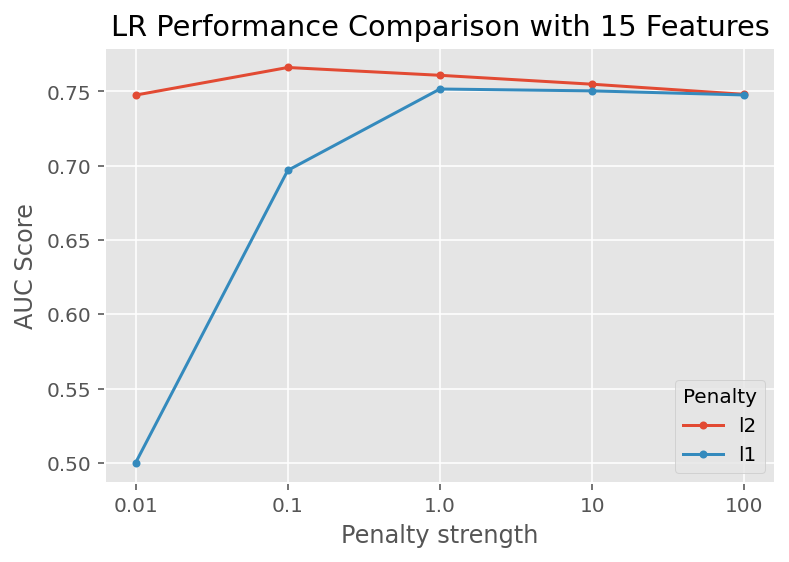

```python
results_LR = get_search_results(gs_pipe_LR)
results_LR_15_features = results_LR[results_LR['rfi_fs__n_features_'] == 15].sort_values('lr__C')
x = [0.01, 0.1, 1.0, 10, 100]
xi = list(range(len(x)))

# plot LR hyperparameter comparison
for i in results_LR_15_features['lr__penalty'].unique():
    temp = results_LR_15_features[(results_LR_15_features['lr__penalty'] == i)]
    plt.plot(xi, temp['mean_score'], marker = '.', label = i)

plt.legend(title = "Penalty")
plt.xlabel('Penalty strength')
plt.ylabel("AUC Score")
plt.xticks(xi, x)
plt.title("LR Performance Comparison with 15 Features")
plt.show()
```

When the logistic regression penalty is set to l1, the penality strength from 0.0.01 to 0.1 shows the AUC score significantly increase before coming to a pleateau at penalty strength of 1.0. On the other hand, when the penalty is set to l2, the AUC score appear to increase gradually till it reaches a max mean AUC score of 0.766 at penalty strength 0.1 before decreases gradually with the increase of penalty strength.

# Performance Comparison

Now that the best hyperparameter values are determined for each classifier, the tuned classifers are tested on the test data using the stratified cross-validation method to find which tuned classifier performs the best.

A five fold cross statified cross validation with three repetition will be performed on each tuned classifier, then pair wise t-tests will be used to determine if the differences in the performace of the classifiers are statistically significant.

### K Nearest Neighbour

```python
from sklearn.model_selection import cross_val_score

cv_method_ttest = RepeatedStratifiedKFold(n_splits=5, n_repeats=3, random_state=999)

cv_results_KNN = cross_val_score(estimator=gs_pipe_KNN.best_estimator_,
                                 X=D_test,
                                 y=t_test,
                                 cv=cv_method_ttest,
                                 n_jobs=-2,
                                 scoring='roc_auc')

cv_results_KNN.mean().round(3)
```

```
0.687
```

```python
from sklearn import metrics
predKNN = gs_pipe_KNN.best_estimator_.predict_proba(D_test)
predKNN[0:10]
```

```
array([[0.33333333, 0.66666667],
       [0.46666667, 0.53333333],
       [0.2       , 0.8       ],
       [0.06666667, 0.93333333],
       [0.06666667, 0.93333333],
       [0.93333333, 0.06666667],
       [0.2       , 0.8       ],
       [0.33333333, 0.66666667],
       [0.2       , 0.8       ],
       [0.06666667, 0.93333333]])
```

```python
fpr, tpr, _ = metrics.roc_curve(t_test, predKNN[:, 1])
```

```python
import pandas as pd
df = pd.DataFrame({'fpr': fpr, 'tpr': tpr})
df.head()
```

|  | fpr | tpr |
| --- | --- | --- |
| 0 | 0.000000 | 0.00 |
| 1 | 0.000000 | 0.01 |
| 2 | 0.113636 | 0.22 |
| 3 | 0.204545 | 0.43 |
| 4 | 0.318182 | 0.62 |

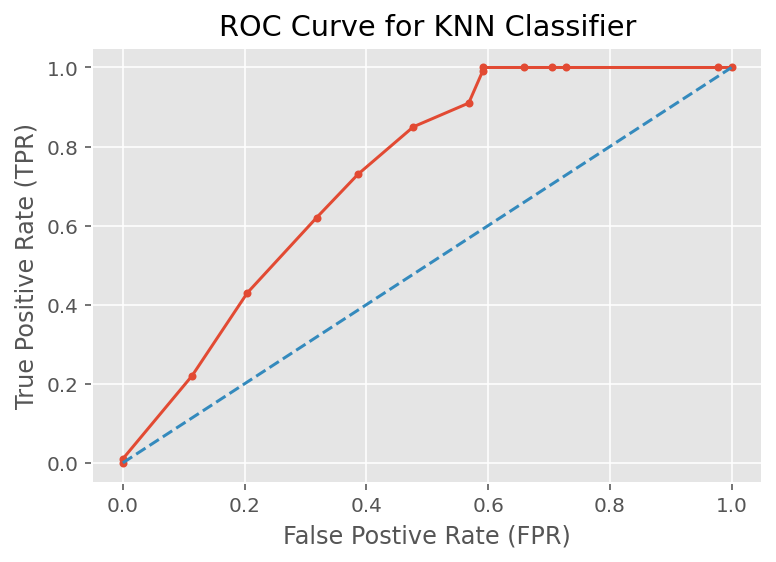

```python
import matplotlib.pyplot as plt
%matplotlib inline
%config InlineBackend.figure_format = 'retina'
plt.style.use("ggplot")

ax = df.plot.line(x='fpr', y='tpr', title='ROC Curve for KNN Classifier', legend=False, marker = '.')
plt.plot([0, 1], [0, 1], '--')
ax.set_xlabel("False Postive Rate (FPR)")
ax.set_ylabel("True Positive Rate (TPR)")
plt.show();
```

## Naive Bayes

```python
Data_test_transformed = PowerTransformer().fit_transform(D_test)

cv_results_NB = cross_val_score(estimator=gs_pipe_NB.best_estimator_,
                                 X=Data_test_transformed,
                                 y=t_test,
                                 cv=cv_method_ttest,
                                 n_jobs=-2,
                                 scoring='roc_auc')
cv_results_NB.mean().round(3)
```

```
0.825
```

```python
predNB = gs_pipe_NB.best_estimator_.predict_proba(D_test)
predNB[0:10]
```

```
array([[0.07446627, 0.92553373],
       [0.118947  , 0.881053  ],
       [0.1180675 , 0.8819325 ],
       [0.07111037, 0.92888963],
       [0.10496784, 0.89503216],
       [0.09991079, 0.90008921],
       [0.10257443, 0.89742557],
       [0.10707328, 0.89292672],
       [0.07580883, 0.92419117],
       [0.10785485, 0.89214515]])
```

```python
fpr, tpr, _ = metrics.roc_curve(t_test, predNB[:, 1])
```

```python
df = pd.DataFrame({'fpr': fpr, 'tpr': tpr})
roc_auc = metrics.auc(fpr, tpr)
roc_auc
```

```
0.5872727272727273
```

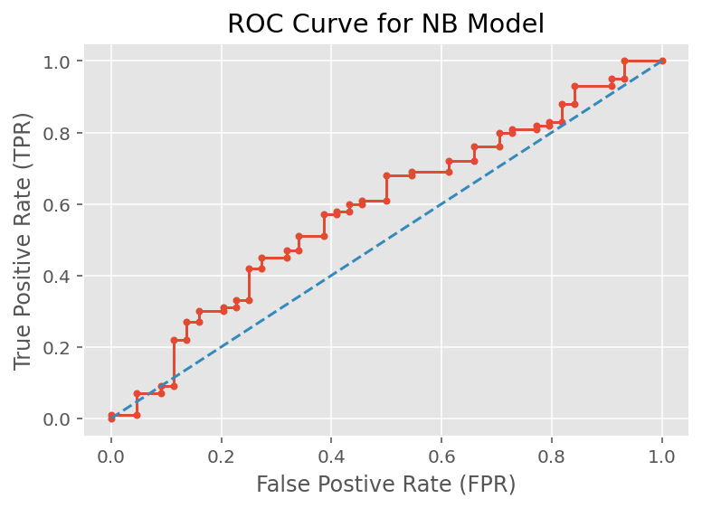

```python
ax = df.plot.line(x='fpr', y='tpr', title='ROC Curve for NB Model', legend=False, marker = '.')
plt.plot([0, 1], [0, 1], '--')
ax.set_xlabel("False Postive Rate (FPR)")
ax.set_ylabel("True Positive Rate (TPR)")
plt.show();
```

## Decision Tree

```python
cv_results_DT = cross_val_score(estimator=gs_pipe_DT.best_estimator_,
                                X=D_test,
                                y=t_test,
                                cv=cv_method_ttest,
                                n_jobs=-2,
                                scoring='roc_auc')
cv_results_DT.mean().round(3)
```

```
0.691
```

```python
predDT = gs_pipe_DT.best_estimator_.predict_proba(D_test)
predDT[0:10]
```

```
array([[0.11504425, 0.88495575],
       [0.23899371, 0.76100629],
       [0.23899371, 0.76100629],
       [0.11504425, 0.88495575],
       [0.23899371, 0.76100629],
       [0.86206897, 0.13793103],
       [0.23899371, 0.76100629],
       [0.23899371, 0.76100629],
       [0.11504425, 0.88495575],
       [0.23899371, 0.76100629]])
```

```python
fpr, tpr, _ = metrics.roc_curve(t_test, predDT[:, 1])
```

```python
df = pd.DataFrame({'fpr': fpr, 'tpr': tpr})
```

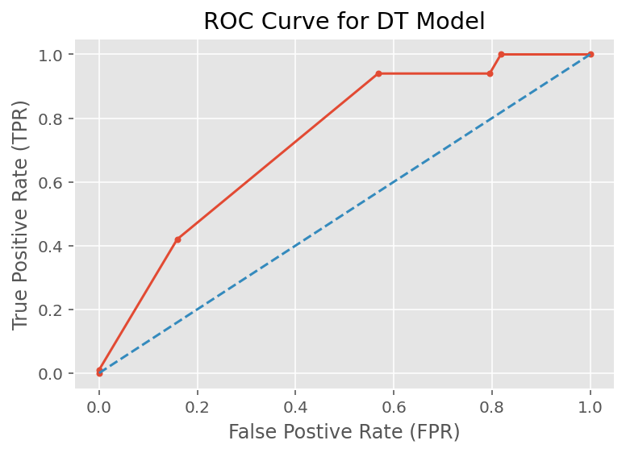

```python
ax = df.plot.line(x='fpr', y='tpr', title='ROC Curve for DT Model', legend=False, marker = '.')
plt.plot([0, 1], [0, 1], '--')
ax.set_xlabel("False Postive Rate (FPR)")
ax.set_ylabel("True Positive Rate (TPR)")
plt.show();
```

## Random Forest

```python
cv_results_RF = cross_val_score(estimator=gs_pipe_RF.best_estimator_,
                                X=D_test,
                                y=t_test,
                                cv=cv_method_ttest,
                                n_jobs=-2,
                                scoring='roc_auc')
cv_results_RF.mean().round(3)
```

```
0.742
```

```python
predRF = gs_pipe_RF.best_estimator_.predict_proba(D_test)

predRF[0:10]
```

```
array([[0.24330759, 0.75669241],
       [0.2107281 , 0.7892719 ],
       [0.26291389, 0.73708611],
       [0.28762179, 0.71237821],
       [0.19263896, 0.80736104],
       [0.70334729, 0.29665271],
       [0.18800525, 0.81199475],
       [0.31486321, 0.68513679],
       [0.19305005, 0.80694995],
       [0.19644233, 0.80355767]])
```

```python
fpr, tpr, _ = metrics.roc_curve(t_test, predRF[:, 1])
roc_auc = metrics.auc(fpr, tpr)
roc_auc
```

```
0.7473863636363637
```

```python
df = pd.DataFrame({'fpr': fpr, 'tpr': tpr})
```

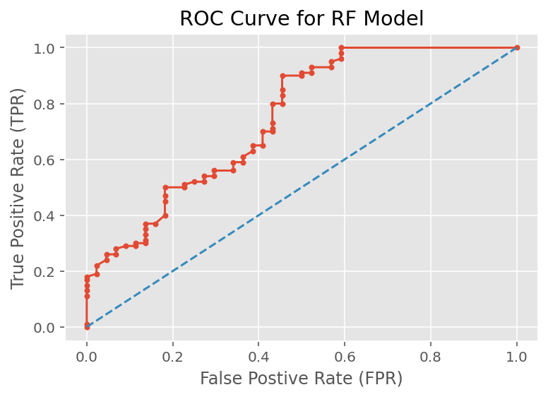

```python
 ax = df.plot.line(x='fpr', y='tpr', title='ROC Curve for RF Model', legend=False, marker = '.')
plt.plot([0, 1], [0, 1], '--')
ax.set_xlabel("False Postive Rate (FPR)")
ax.set_ylabel("True Positive Rate (TPR)")
plt.show();
```

## Logistic Regression

```python
cv_results_LR = cross_val_score(estimator=gs_pipe_LR.best_estimator_,
                                X=D_test,
                                y=t_test,
                                cv=cv_method_ttest,
                                n_jobs=-2,
                                scoring='roc_auc')
cv_results_LR.mean().round(3)
```

```
0.777
```

```python
predLR = gs_pipe_LR.best_estimator_.predict_proba(D_test)
predLR[0:10]
```

```
array([[0.21158768, 0.78841232],
       [0.32916086, 0.67083914],
       [0.32740258, 0.67259742],
       [0.16930411, 0.83069589],
       [0.28131565, 0.71868435],
       [0.59829904, 0.40170096],
       [0.26945361, 0.73054639],
       [0.29005847, 0.70994153],
       [0.2200779 , 0.7799221 ],
       [0.32359609, 0.67640391]])
```

```python
fpr, tpr, _ = metrics.roc_curve(t_test, predLR[:, 1])
roc_auc = metrics.auc(fpr, tpr)
roc_auc
```

```
0.7720454545454545
```

```python
df = pd.DataFrame({'fpr': fpr, 'tpr': tpr})
```

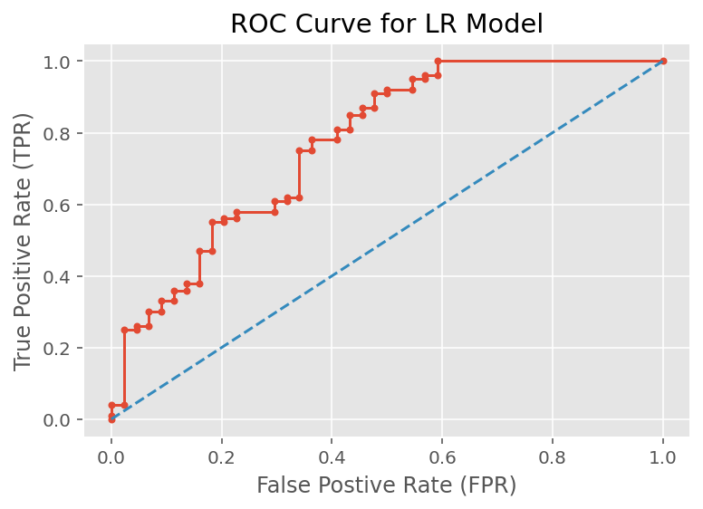

```python
ax = df.plot.line(x='fpr', y='tpr', title='ROC Curve for LR Model', legend=False, marker = '.')
plt.plot([0, 1], [0, 1], '--')
ax.set_xlabel("False Postive Rate (FPR)")
ax.set_ylabel("True Positive Rate (TPR)")
plt.show();
```

[output not shown]

```python
from scipy import stats

print("p-value RF vs LR: ")
print(stats.ttest_rel(cv_results_RF, cv_results_LR).pvalue)
print("---------------------------------")
print("p-value LR vs KNN: ")
print(stats.ttest_rel(cv_results_NB, cv_results_RF).pvalue)
print("---------------------------------")
print("p-value RF vs KNN: ")
print(stats.ttest_rel(cv_results_NB, cv_results_LR).pvalue)
```

```
p-value RF vs LR:
0.39923718969164756
---------------------------------
p-value LR vs KNN:
0.01705178487120631
---------------------------------
p-value RF vs KNN:
0.039491249512007186
```

```python
pred_KNN = gs_pipe_KNN.predict(D_test)

Data_test_transformed = PowerTransformer().fit_transform(D_test)
pred_NB = gs_pipe_NB.predict(Data_test_transformed)

pred_DT = gs_pipe_DT.predict(D_test)

pred_RF = gs_pipe_RF.predict(D_test)

pred_LR = gs_pipe_LR.predict(D_test)
```

```python
from sklearn import metrics

print("************************************************")
print("\nClassification report for Logistic Regression")
print(metrics.classification_report(t_test, pred_LR))
print("************************************************")
print("\nClassification report for Random Forest")
print(metrics.classification_report(t_test, pred_RF))
print("************************************************")
```

```
Classification report for Logistic Regression
              precision    recall  f1-score   support

           0       1.00      0.32      0.48        44
           1       0.77      1.00      0.87       100

    accuracy                           0.79       144
   macro avg       0.88      0.66      0.68       144
weighted avg       0.84      0.79      0.75       144


Classification report for Random Forest
              precision    recall  f1-score   support

           0       0.76      0.43      0.55        44
           1       0.79      0.94      0.86       100

    accuracy                           0.78       144
   macro avg       0.77      0.69      0.70       144
weighted avg       0.78      0.78      0.76       144
```

The F1 scores are then put into place in determining the better model between the LR and the RF model. The F1 score metrics are good alternatives to the AUC metric for datasets with mild class imbalance problems. The F1 score is the weighted average of both precision and recall. The Dream Housing Finance Company earns its income by charging interest from the mortgage loans provided to their clients, therefore, recall will be an important metric to the company. With more people who should get their loans approved correctly identified, the company will be able to generate higher profit by providing more loans to eligible borrowers.

At the same time, it is important that the model is able to correctly identify the loans out of all the loans identified as approved . This is where precision comes into place. With more loans being correctly identified, the company will be able to reduce the chances of a customer defaulting on their loans.

# Limitations

Firstly, RF model requires large computational power as the model builds many trees to capture dataset. This can be computational expensive for a model that suffers from interpretability and may not be the most applicable model for real-time prediction used by Dream Housing Finance company.

For NB, a power transformation is applied to the dataset transforming the descriptive variables to portray more standardized or Gaussian probability distribution. This will affect the dummy features where the variable takes on values of 1 or 0, in this case education, married, gender. In addition, the NB algorithms assume independence of the variable which is highly unlikely in this scenario. For example, the number of dependencies is usually dependent on the martial status and one's income is also dependent on the education level of a person.

Following, the LR model assumes linearity between the dependent variable, target and the independent variables, which is highly unlikely in this scenario. To solve this assumption, transformation of non linear features can be used. The LR algorithms is also built on a high dimensions dataset with 15 features and the model will have the tendency to overfit the training dataset as there is small training dataset with large features.

Likewise, the dataset used to build the models contained only 480 observations. This may have a large impact to our non-parametric models: KNN and DT. Not only do non-parametric algorithms require more data to train the mapping function, but having such a small dataset could potentially also lead to overfitting.

Moreover, the models overall produced in this project did not result in the greatest performance in terms of their performance metrics as majority of the metrics lay between the 0.7 and 0.8 mark. Although not comparable with one another, ideally these performance metrics should be relatively higher. One potential cause for the poor performance of the models is the method of feature selection that was chosen. Instead of using a filter method (RFI) and used across all the classifiers, another direction could be to use a wrapper method and define a classifier for each feature selection procedure. However, the downside to this process is the computation time required to fit all five classifiers, along with taking the hyperparameter tuning and cross-validation steps in mind.

Given this project mainly focused on the accuracy given the project requirements, other aspects may also need to be considered depending on Dream Housing Finance Company's needs. Prediction speed, capacity for retraining and interpretability are also points that may need to be taken into consideration depending on the needs of the company. Further consultation with the company may be necessary in order to choose an aspect to focus on, or to find a balance between the project requirements.

# Summary and Conclusions

## Project Summary

Phase one of this project dealt with retrieving, cleaning and exploring the Dream Housing Financing Company's dataset. Cleaning involved dealing with missing values, removing ID-like columns and creating more informative features. The data was then explored through descriptive statistics and a variety of data visualisations. Univariate plots allowed us to see the distribution of the variables, while bivariate/multivariate plots displayed relationships between some variables. Key takeaways from this process indicated some variables were more predictive of the target variable than others like credit history.

With the preprocessed data and insights in mind, phase two of this project involved exploring and building five different classifer machine learning algorithms to help the Dream Housing Financing Company automate their loan approval predictions. To ensure the model was generalisable to external data, model validation procedures were performed throughout the modelling process. Given the small size of the dataset, the main strategy used for this project was a five fold cross-validation with three repetitions.

First, the data was further processed in preparation for Scikit-Learn's machine learning algorithms. Variables were one-hot encoded then scaled accordingly using the min-max scaling method. Feature selection was performed using the RFI filter method to find the best subset of features for each classifier.

Pipelines were used to stack the feature selection and hyperparameter tuning in a grid search manner. A pipeline for each classifier was created and trained against the train dataset. The average AUC score was used as the metric to find the best performing parameters.

Once each classifier had their hyperparameters tuned and best number of descriptive features found, they were fitted against the test data to produce the performance metrics. Paired sample t-test allowed the comparison between models to find which statistically performed better.

## Summary of Findings

The feature selection stage with the random forest importance method revealed the most predictive descriptive features for this dataset. It especially weighted importance on total household income, credit history and then loan amount.

During the model fitting and hyperparameter tuning phase, it was found there was a variety of number of features needed for each classifier which can be observed in the table below.

| Model | num_features |
| --- | --- |
| LR | 15 |
| RF | 3 |
| KNN | 3 |
| DT | 10 |
| NB | 10 |

## Conclusions

Five machine learning models were created in this project to help classify whether or not an applicant would be approved for their home loan given a set of features. Pipelines were utilised to determine the best set of features and tune the hyperparameters with cross-validation procedures to avoid overfitting.

Despite the logistic regression model performed the best among the five classifiers, it should be used with caution given its relatively poor overall performance and various pitfalls. In addition, the feature selection method chosen could potentially have hindered the training stage of these models, leading to the possibility of a more comprehensive feature selection technique, which could result in a different classifier producing a better performing model.

# References

- Aksakalli, V., Yenice, Z., Wong, Y., Ture, I., & Malekipirbazari, M. SK Part 2: Feature Selection and Ranking | www.featureranking.com. www.featureranking.com. Retrieved 1 June 2021, from https://www.featureranking.com/tutorials/machine-learning-tutorials/sk-part-2-feature-selection-and-ranking/.
- Aksakalli, V., Yenice, Z., Wong, Y., Ture, I., & Malekipirbazari, M. SK Part 3: Cross-Validation and Hyperparameter Tuning | www.featureranking.com. www.featureranking.com. Retrieved 1 June 2021, from https://www.featureranking.com/tutorials/machine-learning-tutorials/sk-part-3-cross-validation-and-hyperparameter-tuning/.
- Aksakalli, V., Yenice, Z., Wong, Y., Ture, I., & Malekipirbazari, M. SK Part 4: Model Evaluation | www.featureranking.com. www.featureranking.com. Retrieved 1 June 2021, from https://www.featureranking.com/tutorials/machine-learning-tutorials/sk-part-4-model-evaluation/.
- Singh, S. (2021). Loan Approval Prediction. Kaggle.com. Retrieved 6 April 2021, from https://www.kaggle.com/sonalisingh1411/loan-approval-prediction.